# Assignment 3

Ilchan Ju

2019-11-12

## 8.3

Hierarchical modeling: The files school1.dat through school8.dat give weekly hours spent on homework for students sampled from eight different schools. Obtain posterior distributions for the true means for the eight different schools using a hierarchical normal model with the following prior parameters: mu0 = 7, g2 = 5, tau2 = 10, eta0 = 2, sigma02 = 15, nu0 = 2

## a

Run a Gibbs sampling algorithm to approximate the posterior distribution of {theta, sigma2, mu,ta2}. Assess the convergence of the Markov chain, and find the effective sample size for {sigma2, mu, tau2}. Run the chain long enough so that the effective sample sizes are all above 1,000.

```r
# Load data
library(dplyr)
```

```r
library(tidyr)
library(ggplot2)
schools.list = lapply(1:8, function(i) {
  s.tbl = paste0('http://www.stat.washington.edu/people/pdhoff/Book/Data/hwdata/school', i, '.dat') %>%
    url %>%
    read.table

  data.frame(
    school = i,
    hours = s.tbl[, 1] %>% as.numeric
  )
})
schools.raw = do.call(rbind, schools.list)
Y = schools.raw
# Prior
mu0 = 7
g20 = 5
t20 = 10
eta0 = 2
s20 = 15
nu0 = 2
# Number of schools. Y[, 1] are school ids
m = length(unique(Y[, 1]))
# Starting values - use sample mean and variance
n = sv = ybar = rep(NA, m)
for (j in 1:m) {
  Y_j = Y[Y[, 1] == j, 2]
  ybar[j] = mean(Y_j)
  sv[j] = var(Y_j)
  n[j] = length(Y_j)
}
# Let initial theta estimates be the sample means
# Similarly, let initial values of sigma2, mu, and tau2 be "sample mean and
# variance"
theta = ybar
sigma2 = mean(sv)
mu = mean(theta)
tau2 = var(theta)
# MCMC
S = 1500
THETA = matrix(nrow = S, ncol = m)
# Storing sigma, mu, theta together
SMT = matrix(nrow = S, ncol = 3)
colnames(SMT) = c('sigma2', 'mu', 'tau2')
for (s in 1:S) {
  # Sample thetas
  for (j in 1:m) {
    vtheta = 1 / (n[j] / sigma2 + 1 / tau2)
    etheta = vtheta * (ybar[j] * n[j] / sigma2 + mu / tau2)
    theta[j] = rnorm(1, etheta, sqrt(vtheta))
  }

  # Sample sigma2
  nun = nu0 + sum(n) # TODO: Could cache this
  ss = nu0 * s20

  # Pool variance
  for (j in 1:m) {
    ss = ss + sum((Y[Y[, 1] == j, 2] - theta[j])^2)
  }
  sigma2 = 1 / rgamma(1, nun / 2, ss / 2)

  # Sample mu
  vmu = 1 / (m / tau2 + 1 /g20)
  emu = vmu * (m * mean(theta) / tau2 + mu0 / g20)
  mu = rnorm(1, emu, sqrt(vmu))

  # Sample tau2
  etam = eta0 + m
  ss = eta0 * t20 + sum((theta - mu)^2)
  tau2 = 1 / rgamma(1, etam / 2, ss / 2)

  # Store parameters
  THETA[s, ] = theta
  SMT[s, ] = c(sigma2, mu, tau2)
}
```

With diagnostic boxplots

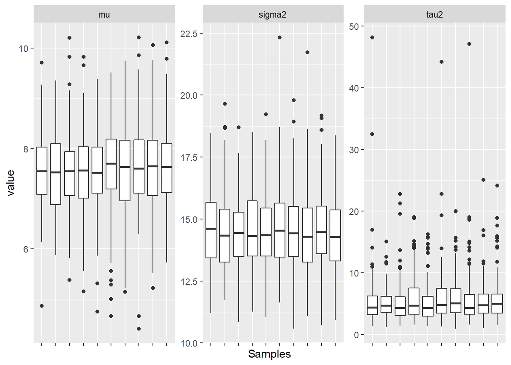

Evaluate effective sample size

```r
# samples until all of the below are above 1000
library(coda)
effectiveSize(SMT[, 1])
```

```
##     var1
## 1628.363
```

```r
effectiveSize(SMT[, 2])
```

```
##     var1
## 1308.235
```

```r
effectiveSize(SMT[, 3])
```

```
##     var1
## 1130.053
```

## b

Compute posterior means and 95% confidence regions for {sigma2, mu, tau2}. Also, compare the posterior densities to the prior densities, and discuss what was learned from the data.

```r
t(apply(SMT, MARGIN = 2, FUN = quantile, probs = c(0.025, 0.5, 0.975)))
```

```
##            2.5%       50%     97.5%
## sigma2 11.89887 14.403131 17.909908
## mu      5.92421  7.589274  9.154428
## tau2    1.82237  4.641758 14.674292
```

Comparing posterior to prior:

```r
# For dinvgamma
library(MCMCpack)
```

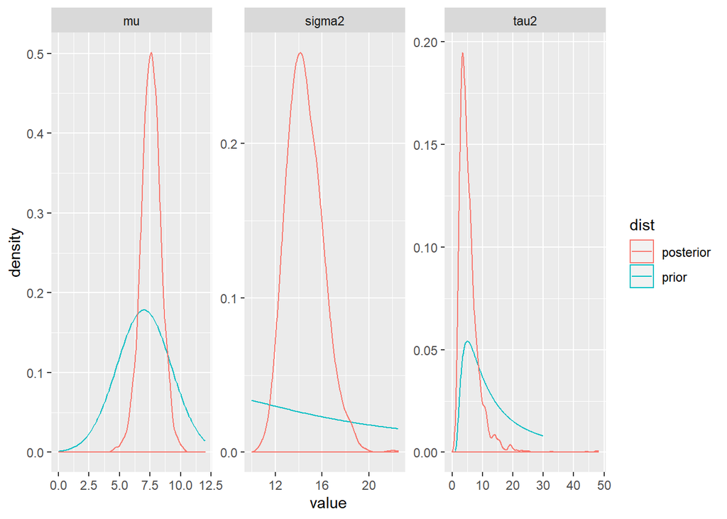

```r
sigma2_prior = data.frame(
  value = seq(10, 22.5, by = 0.1),
  density = dinvgamma(seq(10, 22.5, by = 0.1), nu0 / 2, nu0 * s20 / 2),
  variable = 'sigma2'
)
tau2_prior = data.frame(
  value = seq(0, 30, by = 0.1),
  density = dinvgamma(seq(0, 30, by = 0.1), eta0 / 2, eta0 * t20 / 2),
  variable = 'tau2'
)
mu_prior = data.frame(
  value = seq(0, 12, by = 0.1),
  density = dnorm(seq(0, 12, by = 0.1), mu0, sqrt(g20)),
  variable = 'mu'
)
priors = rbind(sigma2_prior, tau2_prior, mu_prior)
priors$dist = 'prior'
smt.df$dist = 'posterior'
ggplot(priors, aes(x = value, y = density, color = dist)) +
  geom_line() +
  geom_density(data = smt.df, mapping = aes(x = value, y = ..density..)) +
  facet_wrap(~ variable, scales = 'free')
```

## c

Plot the posterior density of R = $\tau^2$/($\sigma^2$+$\tau^2$) and compare it to a plot of theprior density of R. Describe the evidence for between-school variation.

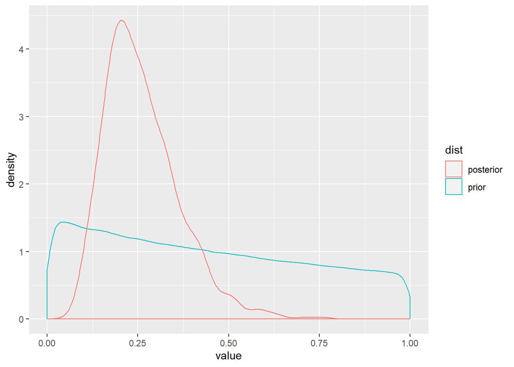

```r
t20_prior = (1 / rgamma(1e6, eta0 / 2, eta0 * t20 / 2))
s20_prior = (1 / rgamma(1e6, nu0 / 2, nu0 * s20 / 2))
R_prior = data.frame(
  value = (t20_prior) / (t20_prior + s20_prior),
  dist = 'prior'
)
R_post = data.frame(
  value = SMT[, 'tau2'] / (SMT[, 'tau2'] + SMT[, 'sigma2']),
  dist = 'posterior'
)
ggplot(R_prior, aes(x = value, y = ..density.., color = dist)) +
  geom_density(data = R_prior) +
  geom_density(data = R_post)
```

```r
mean(R_post$value)
```

```
## [1] 0.26125
```

$R$ : how much of the total variance in our data is between-group. Prior didn’t contain much information about this value, but after the inference, we expect that around 25% of our variance comes from between group variance : ($\tau^2$).

## d

Obtain the posterior probability that theta7 is smaller than theta6, as well as the posterior probability that theta7 is the smallest of all the theta’s.

```r
theta7_lt_6 = THETA[, 7] < THETA[, 6]
mean(theta7_lt_6)
```

```
## [1] 0.508
```

```r
theta7_smallest = (THETA[, 7] < THETA[, -7]) %>%
  apply(MARGIN = 1, FUN = all)
mean(theta7_smallest)
```

```
## [1] 0.3026667
```

## e

Plot the sample averages bar of (y1, . . . , y8) against the posterior expectations of theta1, . . . , theta8, and describe the relationship. Also compute the sample mean of all observations and compare it to the posterior mean of mu.

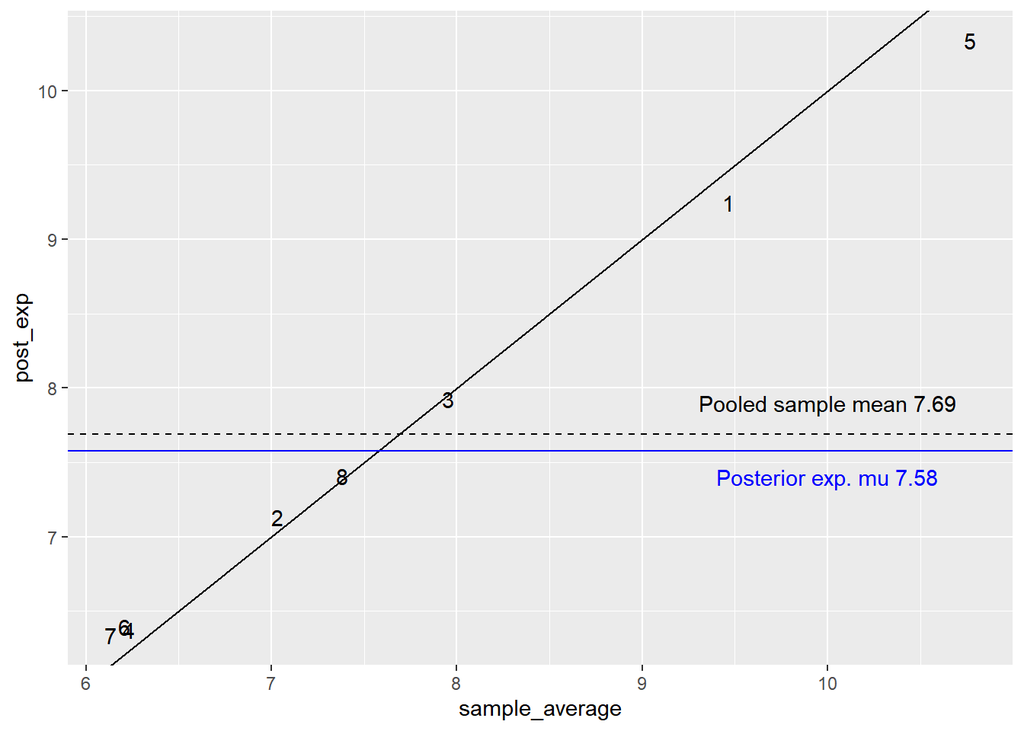

```r
relationship = data.frame(
  sample_average = ybar,
  post_exp = colMeans(THETA),
  school = 1:length(ybar)
)
ggplot(relationship, aes(x = sample_average, y = post_exp, label = school)) +
  geom_text() +
  geom_abline(slope = 1, intercept = 0) +
  geom_hline(yintercept = mean(schools.raw[, 'hours']), lty = 2) +
  annotate('text', x = 10, y = 7.9, label = paste0("Pooled sample mean ", round(mean(schools.raw[, 'hours']), 2))) +
  geom_hline(yintercept = mean(SMT[, 'mu']), color = 'blue') +
  annotate('text', x = 10, y = 7.4, label = paste0("Posterior exp. mu ", round(mean(SMT[, 'mu']), 2)), color = 'blue')
```